# evaluate_classes

Now, let's evaluate our model on the test data. We've already loaded a trained model under `/creatica/code/model`, so we can load it later. Let's start!

### Importing libraries and defining paths and constants

```python
import os
import argparse
import simplejson
import matplotlib.pyplot as plt
import cv2

import numpy as np
import glob

import tensorflow as tf
import keras
from keras.models import model_from_json
from keras.preprocessing.image import ImageDataGenerator, array_to_img, img_to_array, load_img
from keras.applications.inception_v3 import InceptionV3, preprocess_input

keras.backend.clear_session()
```

```python
#define paths and constants
data_path = "/Users/victorialiu/git/creatica/code/data/"
test_img_path = os.path.join(data_path, 'test')
batch_size = 16
TARGET_SIZE = 299
```

### Command Line Argument Parser

We want to be able to run our code from the command line (at least in the `.py` version of this notebook), so we use an argument parser to translate command line arguments. We require a model name when running the script, the same model that was saved earlier.

```python
## Parse command line arguments
def parse_args():
    parser = argparse.ArgumentParser()
    parser.add_argument('-m', '--model-name',
        help='prefix for saved trained model we want to evaluate ' +
            '(e.g. dense_arch1, conv_regularize05, etc.)',
        required=True)
    return parser.parse_args()
```

### Image Pre-processing with InceptionV3 net

Here, we pre-process our images by extracting their features using InceptionV3.

```python
def get_data():
    #load training data and define labels, where 0 is hotdog and 1 is nothotdog
    train_data = np.load('inception_features_train.npz')['features']

    #requires the number of hotdog and nothotdog samples to be the exact same
    train_data_type_count = int(len(train_data) / 3)
    train_labels = np.array(
        [0] * train_data_type_count +
        [1] * train_data_type_count +
        [2] * train_data_type_count
        )

    #load testing data and define labels, where 0 is hotdog and 1 is nothotdog
    test_data = np.load('inception_features_test.npz')['features']

    #requires the number of hotdog and nothotdog samples to be the exact same
    test_data_type_count = int(len(test_data) / 3)
    test_labels = np.array(
        [0] * test_data_type_count +
        [1] * test_data_type_count +
        [2] * test_data_type_count
        )

    # Convert labels to one-hot vectors (probability distributions w/
    # probability 1 assigned to the correct label)
    train_labels = keras.utils.to_categorical(train_labels)
    test_labels = keras.utils.to_categorical(test_labels)

    return (train_data, train_labels, test_data, test_labels)
train_data, train_labels, test_data, test_labels = get_data()
```

### Get all incorrectly classified images

Lots of indices and logic-ing here, but we're just extracting the file paths of all the incorrectly classified images, so that we can take a look at them. The `get_image()` function also saves the plot under `/creatica/code/img`, and when run on the command line, the incorrectly classified pictures will pop up one by one.

```python
def incorrect_labels_indices(rounded_predictions, test_labels):
    incorrect_classification_indices = []
    incorrect_labels_of_misclassified = []
    correct_labels_of_misclassified = []
    for i in range(rounded_predictions.shape[0]):
        if rounded_predictions[i] != np.argmax(
            test_labels[i], axis = -1
            ):
            incorrect_classification_indices.append(i)
            correct_labels_of_misclassified.append(np.argmax(test_labels[i], axis = -1))
            incorrect_labels_of_misclassified.append(rounded_predictions[i])
#     print(f'correct labels: \n {correct_labels_of_misclassified}')
    return (
        incorrect_classification_indices,
        correct_labels_of_misclassified,
        incorrect_labels_of_misclassified
        )
```

```python
def get_incorrect_classification_fpaths(incorrect_tuple, rounded_predictions):
    """
    incorrect_tuple of form:
    (incorrect_classification_indices, correct_labels)
    """
    #how many pictures per category (should be 50 for every class)
    index_offset = len(glob.glob(os.path.join(data_path, 'test/hotdog/*.jpg')))

    #keep track of file paths of incorrect pictures for plotting
    incorrect_classification_file_paths = []


    #dictionary of one hot vectors to categories
    one_hot_categories = {
        0 : 'bananas',
        1 : 'carrots',
        2 : 'hotdog'
    }

#     print(f'len incorrect tuple: {len(incorrect_tuple)}')

    incorrect_classification_indices, correct_labels_of_misclassified, _ = incorrect_tuple
    #get incorrect file paths and true values
    for j in range(len(correct_labels_of_misclassified)):
        i = incorrect_classification_indices[j] % index_offset
        incorrect_classification_file_paths.append(
            os.path.join(
            f'{one_hot_categories[correct_labels_of_misclassified[j]]}', os.listdir(
            os.path.join(test_img_path, f'{one_hot_categories[correct_labels_of_misclassified[j]]}')
                )[i]
            ))
    return incorrect_classification_file_paths



def get_image(file_path, pred_value, true_value, cwd, model_name, i):
    one_hot_categories = {
        0 : 'bananas',
        1 : 'carrots',
        2 : 'hotdog'
    }

    pred_value = one_hot_categories[pred_value]
    true_value = one_hot_categories[true_value]
    if '.DS_Store' in file_path:
        pass

    elif os.path.isfile(
            os.path.join(test_img_path, file_path)):
        image_bgr = cv2.imread(os.path.join(test_img_path, file_path),cv2.IMREAD_COLOR)
        image_rgb = cv2.cvtColor(image_bgr, cv2.COLOR_BGR2RGB)
        image_rgb_resized = cv2.resize(image_rgb, (TARGET_SIZE, TARGET_SIZE), interpolation = cv2.INTER_CUBIC)
        plt.imshow(image_rgb_resized)
        plt.axis("off")
        plt.title('Pred: %s\nTrue: %s' % (pred_value, true_value))
        plt.savefig(os.path.join(cwd, 'img', '%s_mistake_%s.png') % (model_name, str(i)))
        plt.show()
```

### Let's Go!!

Here, we write the main function the command line executes.. we'll print out the training loss, training accuracy, validation loss, and validation accuracy. Remember, we are doing binary cross-entropy for loss and binary accuracy for accuracy.

```
Training loss: 0.12234710156917572
Training accuracy: 0.9425837397575378

Validation loss: 0.15481112897396088
Validation accuracy: 0.9200000166893005
Some incorrectly classified images
```

[figure not shown]

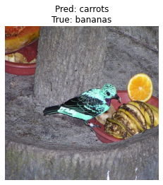

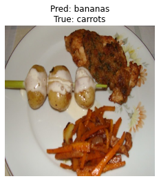

[figure not shown]

[figure not shown]

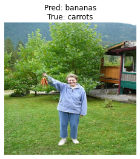

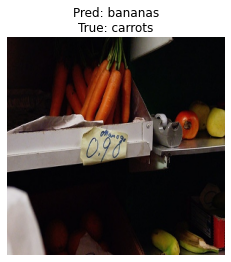

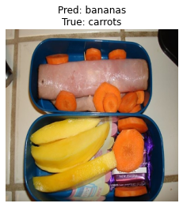

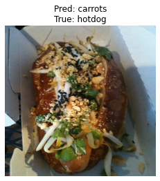

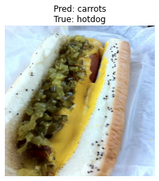

```
array([0, 0, 0, 0, 0, 0, 0, 0, 1, 0, 0, 0, 0, 0, 0, 0, 0, 0, 0, 0, 1, 0,
       0, 0, 0, 0, 0, 0, 0, 0, 0, 0, 0, 0, 0, 0, 0, 0, 0, 0, 0, 0, 0, 0,
       0, 0, 0, 0, 0, 0, 1, 1, 0, 1, 1, 1, 1, 1, 1, 1, 1, 1, 1, 0, 1, 1,
       1, 1, 1, 1, 1, 1, 1, 1, 0, 1, 1, 0, 1, 1, 1, 1, 1, 1, 1, 1, 1, 1,
       1, 1, 1, 1, 0, 1, 1, 1, 1, 1, 0, 1, 2, 2, 2, 2, 2, 2, 2, 2, 1, 2,
       2, 2, 2, 2, 2, 2, 2, 2, 2, 2, 2, 2, 2, 2, 2, 1, 2, 2, 2, 2, 2, 2,
       2, 2, 2, 1, 2, 2, 1, 2, 2, 2, 2, 2, 2, 2, 2, 2, 2, 2])
```

```python
def main():
    # comment out if using command line
    model_name = 'multiclass_debugging'

#    # comment out if running from ipynb
#     args = parse_args()
#     model_name = args.model_name


    # Remove src from cwd if necessary
    cwd = os.getcwd()
    if os.path.basename(cwd) == 'src': cwd = os.path.dirname(cwd)

    # Create img directory to save images if needed
    os.makedirs(os.path.join(cwd, 'img'), exist_ok=True)

    # Create model directory to save models if needed
    os.makedirs(os.path.join(cwd, 'model'), exist_ok=True)
    model_weights_fname = os.path.join(cwd, 'model', model_name + '.h5')
    model_json_fname = os.path.join(cwd, 'model', model_name + '.json')

    # Load hotdog model and its weights
    with open(model_json_fname, 'r') as f: model_json = f.read()
    model = model_from_json(model_json)
    model.load_weights(model_weights_fname)

    # Get hotdog data
    (train_data, train_labels, test_data, test_labels) = get_data()

    # Compile model and evaluate its performance on training and test data
    model.compile(loss='binary_crossentropy', optimizer='adam',
        metrics=['accuracy'])

    score = model.evaluate(train_data, train_labels, verbose=0)
    print()
    print('Training loss:', score[0])
    print('Training accuracy:', score[1])

    score = model.evaluate(test_data, test_labels, verbose=0)
    print()
    print('Validation loss:', score[0])
    print('Validation accuracy:', score[1])


    #print and save pictures that were inaccurately classified?
    # use previously written helper functions to find incorrect classification indices,
    # and the file paths to incorrectly classified images
    rounded_predictions = np.argmax(model.predict(test_data, batch_size=batch_size, verbose=1), axis = -1)


    #get incorrectly classified indices and their labels
    incorrect_tuple = incorrect_labels_indices(
        rounded_predictions, test_labels
        )

    #get file paths for incorrectly categorized pics to plot them later
    incorrect_classification_file_paths = get_incorrect_classification_fpaths(
        incorrect_tuple,
        rounded_predictions
        )

    #get correct_labels
    _, correct_labels_of_misclassified, incorrect_labels_of_misclassified = incorrect_tuple



    for i in range(len(correct_labels_of_misclassified)):
        #let's print every 10th image for fun
        if i // 10 == 0:
            get_image(
                incorrect_classification_file_paths[i],
                incorrect_labels_of_misclassified[i],
                correct_labels_of_misclassified[i],
                cwd, model_name, i
                )
    return rounded_predictions

# if __name__ == '__main__': main()

main()
```

Interesting. I can definitely see why some of the images were falsely classified as they were... hopefully the computer's vision will get better in the future!

**Authors**: Victoria Liu and Gloria Liu

**Last modified**: November 2020

Description: A script to evaluate a saved neural net that should recognize hot dogs vs. carrots vs. bananas.

**Credits**: Parts of the code are originally part of a Caltech extra credit assignment (CS 156a), where Aadyot Bhatnagar wrote the parse_args() function. The image augmentation code is heavily modified from [J-Yash's open-source code](https://github.com/J-Yash/Hotdog-Not-Hotdog).